# Лабораторная работа №13

Программирование в командном процессоре ОС UNIX. Ветвления и циклы

Липатников Андрей

1032253853@rudn.ru

Российский университет дружбы народов

2026-10-08

# Информация

## Докладчик

- Липатников Андрей
- Студент НКАбд-04-25
- Российский университет дружбы народов
- 1032253853@rudn.ru

# Вводная часть

## Актуальность

- bash — основной инструмент автоматизации в UNIX/Linux
- ветвления и циклы — основа сложных командных файлов
- getopts позволяет разбирать флаги командной строки
- навык необходим для администрирования и разработки

## Объект и предмет исследования

- **Объект**: командная оболочка ОС UNIX
- **Предмет**: логические управляющие конструкции и циклы в командных файлах

## Цели и задачи

- **Цель**: изучить основы программирования в оболочке ОС UNIX; научиться писать более сложные командные файлы с использованием логических управляющих конструкций и циклов.
- **Задачи**:
- изучить getopts и разбор флагов командной строки
- написать поиск строк с ключами
- написать программу на C + скрипт анализа `$?`
- написать скрипт создания/удаления N файлов
- написать скрипт упаковки tar + find

## Материалы и методы

- ОС: Fedora 41 (Sway), оболочка bash
- инструменты: bash, grep, getopts, gcc, tar, find
- рабочий каталог: `~/work/study/2025-2026/Операционные системы/os-intro/labs/lab13`
- 4 скрипта + 1 программа на C, 9 снимков

# Содержание исследования

## Команда getopts

- Синтаксис: `getopts option-string variable [arg ...]`
- Флаги с аргументами обозначаются двоеточием: `i:o:p:Cn`
- `OPTARG` — значение аргумента; `OPTIND` — индекс
- Используется в цикле `while` + `case`

## Логические конструкции

Таблица 1: Логические конструкции bash

| Конструкция | Назначение |
| --- | --- |
| `if … then … fi` | Условное выполнение |
| `case … esac` | Выбор из вариантов |
| `&&`, `\\|\\|`, `!` | Логические связки |
| `break` | Выход из цикла |
| `continue` | Пропуск итерации |

## Циклы и true/false

| Цикл | Назначение |
| --- | --- |
| `for i in …` | Перебор списка |
| `while условие` | Пока **истинно** |
| `until условие` | Пока **ложно** |

- `true` — всегда возвращает 0 (истина).
- `false` — всегда возвращает ненулевой код (ложь).

## Задание 1. search.sh — getopts + grep

- Ключи: `-i` (вход), `-o` (выход), `-p` (шаблон), `-C` (регистр), `-n` (номера строк)
- Поиск строк по шаблону в указанном файле

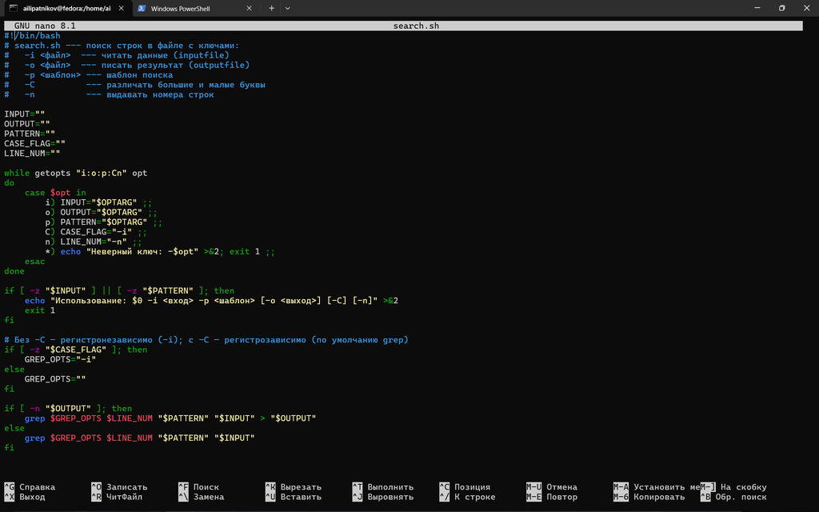

Скрипт search.sh

## Задание 1. Результат

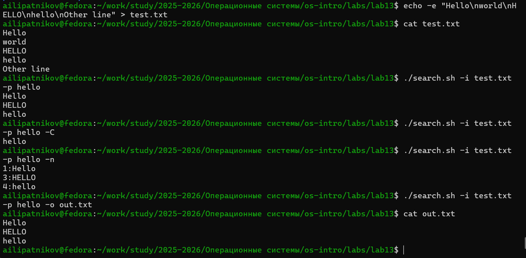

Запуск search.sh

- Без `-C` → `Hello`, `HELLO`, `hello` (3 строки)
- С `-C` → `hello` (1 строка)
- С `-n` → добавлены номера строк
- С `-o` → вывод в файл

## Задание 2. Программа на C

- `check.c` определяет, больше/меньше/равно нулю
- Возвращает код через `exit(n)`:
  - `0` — больше нуля
  - `1` — меньше нуля
  - `3` — равно нулю
  - `2` — ошибка ввода

[figure not shown]

Программа check.c

## Задание 2. Результат

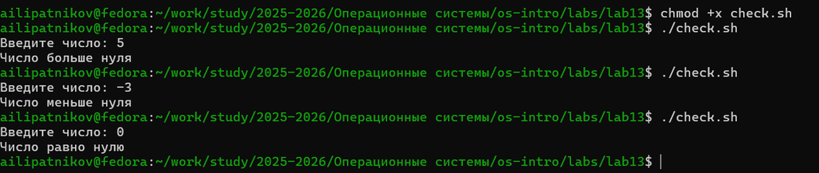

- `gcc -o check check.c` — компиляция
- `check.sh` вызывает программу и анализирует `$?`
- `case $rc in … esac` — вывод по коду

## Задание 3. mkfiles.sh

- Создаёт/удаляет N файлов: `1.tmp`, `2.tmp`, …, `N.tmp`
- Аргументы: `<N>` и `<create|delete>`
- Цикл `for` + `seq`, проверка `-f`

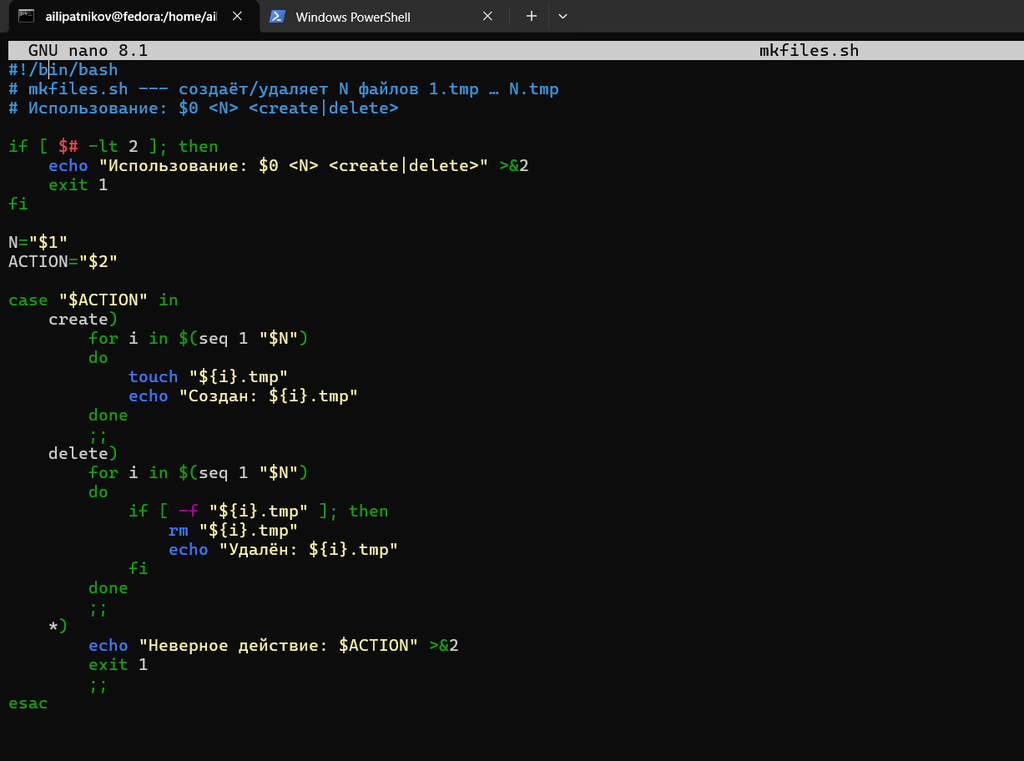

Скрипт mkfiles.sh

## Задание 3. Результат

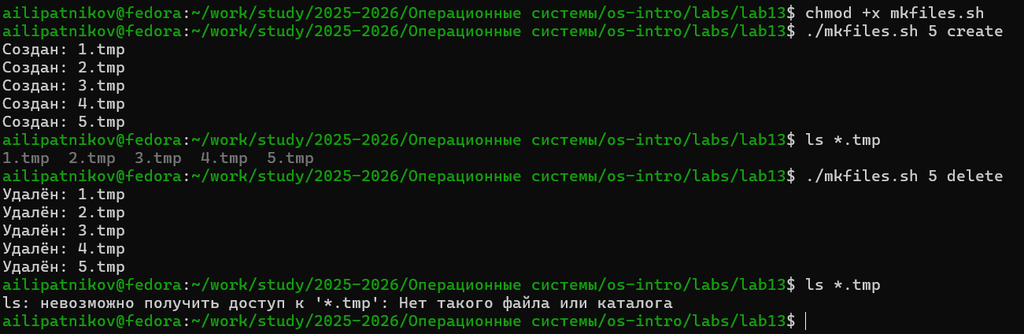

Запуск mkfiles.sh

- `./mkfiles.sh 5 create` → 1.tmp … 5.tmp
- `./mkfiles.sh 5 delete` → все удалены

## Задание 4. backup_dir.sh

- Упаковка каталога в архив `tar`
- Режим `-recent`: только файлы за последнюю неделю
- Связка `find -mtime -7` + `tar --files-from=-`

[figure not shown]

Скрипт backup_dir.sh

## Задание 4. Первый запуск

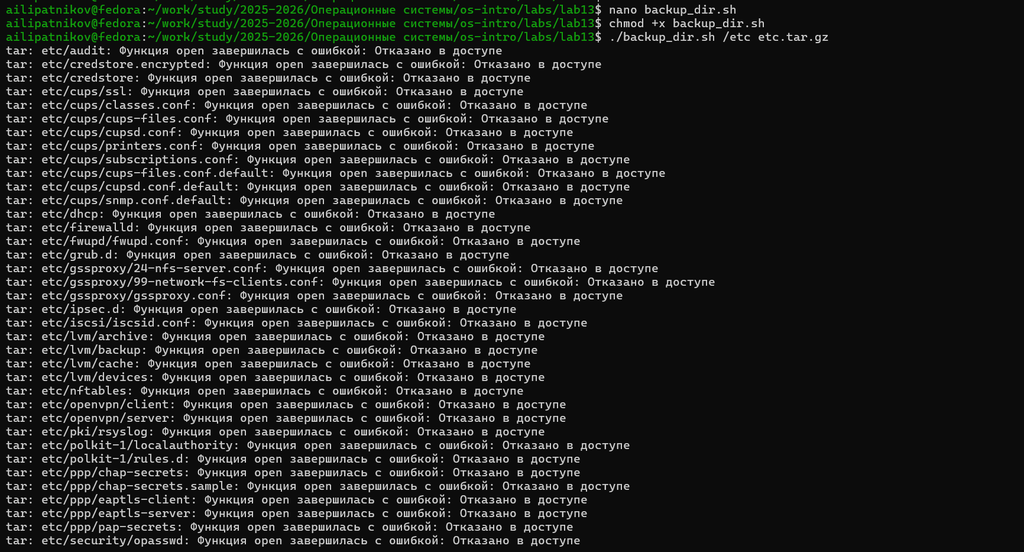

chmod +x и запуск backup_dir.sh /etc etc.tar.gz

- `chmod +x backup_dir.sh` — сделать исполняемым
- `./backup_dir.sh /etc etc.tar.gz` — упаковка всего каталога

## Задание 4. Проверка и режим -recent

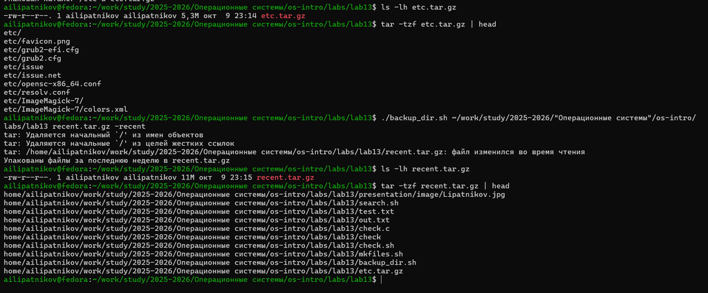

Проверка архивов и запуск с -recent

- `ls -lh etc.tar.gz` — размер архива
- `tar -tzf etc.tar.gz | head` — содержимое
- `./backup_dir.sh ... recent.tar.gz -recent` — только свежие файлы
- `ls -lh recent.tar.gz` + `tar -tzf recent.tar.gz | head`

# Результаты

## Полученные результаты

Таблица 2: Сводка результатов

| Задание | Файл | Результат |
| --- | --- | --- |
| 1 | `search.sh` | Поиск строк с getopts + grep |
| 2 | `check.c` + `check.sh` | Программа на C + анализ `$?` |
| 3 | `mkfiles.sh` | Создание/удаление N файлов |
| 4 | `backup_dir.sh` | Упаковка tar + find -mtime |

## Ключевые конструкции

Таблица 3: Ключевые конструкции

| Элемент | Пример |
| --- | --- |
| getopts | `while getopts "i:o:p:Cn" opt` |
| if | `if [ -z "$VAR" ]; then …` |
| case | `case $rc in 0) … esac` |
| for | `for i in $(seq 1 "$N"); do … done` |
| while | `while [ $i -lt 5 ]; do … done` |
| until | `until [ $i -ge 5 ]; do … done` |

# Заключение

## Главный вывод

bash предоставляет полный набор инструментов для написания сложных командных файлов: разбор флагов через `getopts`, ветвления (`if`, `case`), циклы (`for`, `while`, `until`). Разработанные скрипты (поиск строк, анализ `$?`, создание/удаление N файлов, упаковка tar + find) демонстрируют применимость этих конструкций для задач администрирования и автоматизации в UNIX/Linux.